# Part I - Prosper loan Dataset

## Introduction

This dataset contains data on 113,937 loan from 2005 to 2014 with 81 variables on each loancopy. These variables include loan amount, borrower rate, loan status, borrower income, prosper rating and many others.

## Preliminary Wrangling

```python
# import all packages and set plots to be embedded inline
import numpy as np
import pandas as pd
import matplotlib.pyplot as plt
import seaborn as sb

%matplotlib inline
```

```python
loan = pd.read_csv('/Users/zom3/Project 3/Zainab Mustapha_Project 3/prosperLoanData.csv')
```

```python
loan.head()
```

|  | ListingKey | ListingNumber | ListingCreationDate | CreditGrade | Term | LoanStatus | ClosedDate | BorrowerAPR | BorrowerRate | LenderYield | ... | LP_ServiceFees | LP_CollectionFees | LP_GrossPrincipalLoss | LP_NetPrincipalLoss | LP_NonPrincipalRecoverypayments | PercentFunded | Recommendations | InvestmentFromFriendsCount | InvestmentFromFriendsAmount | Investors |
| --- | --- | --- | --- | --- | --- | --- | --- | --- | --- | --- | --- | --- | --- | --- | --- | --- | --- | --- | --- | --- | --- |
| 0 | 1021339766868145413AB3B | 193129 | 2007-08-26 19:09:29.263000000 | C | 36 | Completed | 2009-08-14 00:00:00 | 0.16516 | 0.1580 | 0.1380 | ... | -133.18 | 0.0 | 0.0 | 0.0 | 0.0 | 1.0 | 0 | 0 | 0.0 | 258 |
| 1 | 10273602499503308B223C1 | 1209647 | 2014-02-27 08:28:07.900000000 | NaN | 36 | Current | NaN | 0.12016 | 0.0920 | 0.0820 | ... | 0.00 | 0.0 | 0.0 | 0.0 | 0.0 | 1.0 | 0 | 0 | 0.0 | 1 |
| 2 | 0EE9337825851032864889A | 81716 | 2007-01-05 15:00:47.090000000 | HR | 36 | Completed | 2009-12-17 00:00:00 | 0.28269 | 0.2750 | 0.2400 | ... | -24.20 | 0.0 | 0.0 | 0.0 | 0.0 | 1.0 | 0 | 0 | 0.0 | 41 |
| 3 | 0EF5356002482715299901A | 658116 | 2012-10-22 11:02:35.010000000 | NaN | 36 | Current | NaN | 0.12528 | 0.0974 | 0.0874 | ... | -108.01 | 0.0 | 0.0 | 0.0 | 0.0 | 1.0 | 0 | 0 | 0.0 | 158 |
| 4 | 0F023589499656230C5E3E2 | 909464 | 2013-09-14 18:38:39.097000000 | NaN | 36 | Current | NaN | 0.24614 | 0.2085 | 0.1985 | ... | -60.27 | 0.0 | 0.0 | 0.0 | 0.0 | 1.0 | 0 | 0 | 0.0 | 20 |

5 rows × 81 columns

```python
#creating a copy of the dataset
loancopy = loan.copy()
```

```python
loancopy.shape
```

```
(113937, 81)
```

```python
loancopy.info()
```

```
<class 'pandas.core.frame.DataFrame'>
RangeIndex: 113937 entries, 0 to 113936
Data columns (total 81 columns):
 #   Column                               Non-Null Count   Dtype
---  ------                               --------------   -----
 0   ListingKey                           113937 non-null  object
 1   ListingNumber                        113937 non-null  int64
 2   ListingCreationDate                  113937 non-null  object
 3   CreditGrade                          28953 non-null   object
 4   Term                                 113937 non-null  int64
 5   LoanStatus                           113937 non-null  object
 6   ClosedDate                           55089 non-null   object
 7   BorrowerAPR                          113912 non-null  float64
 8   BorrowerRate                         113937 non-null  float64
 9   LenderYield                          113937 non-null  float64
```

[output cut: 73 more lines]

```python
sum(loancopy.BorrowerAPR.isnull())
```

```
25
```

```python
sum(loancopy.BorrowerState.isnull())
```

```
5515
```

### Quality and tidiness issue

1. ListingCreationDate, Datecreditpulled and ClosedDate are not datetime objects
2. There are rows with null values in BorrowerAPR column

```python
#converting Listing creation date to datetime object
loancopy['ListingCreationDate'] = pd.to_datetime(loancopy['ListingCreationDate'])
```

```python
#creating a new column listing_year
Listing_year=loancopy.ListingCreationDate.apply(lambda x: x.year)
```

```python
Listing_year.max()
```

```
2014
```

```python
Listing_year.min()
```

```
2005
```

```python
#convert Date credit pulled into a datetime object
loancopy['DateCreditPulled'] = pd.to_datetime(loancopy['DateCreditPulled'])
```

```python
#convert Closed date pulled into a datetime object
loancopy['ClosedDate'] = pd.to_datetime(loancopy['ClosedDate'])
```

```python
#Fill the null values in Borrower APR with the median vlaues
loancopy['BorrowerAPR'] = loancopy['BorrowerAPR'].fillna(loancopy.BorrowerAPR.median())
```

```python
#confirming that all the null values have been fixed
loancopy.BorrowerAPR.info()
```

```
<class 'pandas.core.series.Series'>
RangeIndex: 113937 entries, 0 to 113936
Series name: BorrowerAPR
Non-Null Count   Dtype
--------------   -----
113937 non-null  float64
dtypes: float64(1)
memory usage: 890.3 KB
```

### What is the structure of your dataset?

The dataset has about 113,937 rows and 81 coulumns. The columns mostly contain numerical values in both integer and float formats. There are also datetime objects. The column labels are descriptive. Notably, some columns contain null values. Overall, the data frame presents different details about the loan borrowers and lender.

### What is/are the main feature(s) of interest in your dataset?

Combination of visual and programmatic assessments, and review of dataset documentation makes the following features more interesting in drawing conclusions about the dataset. loan status, lender yield, prosper rating, prospser score, borrower APR, loan amount, is borrower home owner or not, state of borrower, income range of borrowers, and employment status.

### Questions posed

1. What factors affect a loan’s outcome status?
2. What affects the borrower’s APR?
3. What factors affect loan amount?

### What features in the dataset do you think will help support your investigation into your feature(s) of interest?

BorrowerRate, BorrowerAPR, EstimatedLoss, ProsperScore, ListingCatgory, Occupation, Employmentstatus, employment status duration, isborrowerhomeowner, income range, loan original amount, loan term, listingcategory

## Univariate Exploration

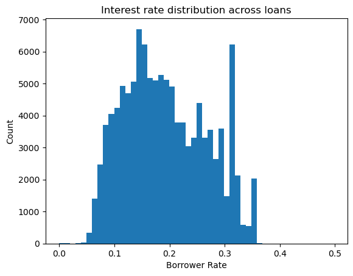

```python
#creating a histogram to view the distribution of Borrower rate across the data frame
plt.hist(data=loancopy, x='BorrowerRate', bins=50);
plt.xlabel('Borrower Rate')
plt.ylabel('Count')
plt.title('Interest rate distribution across loans');
```

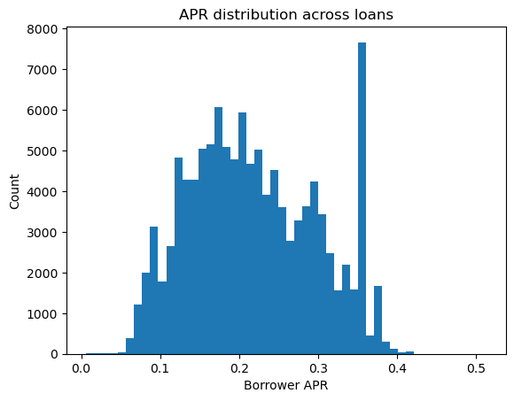

```python
#creating a histogram to view the distribution of Borrower APR across the data frame
plt.hist(data=loancopy, x='BorrowerAPR', bins=50);
plt.xlabel('Borrower APR')
plt.ylabel('Count')
plt.title('APR distribution across loans');
```

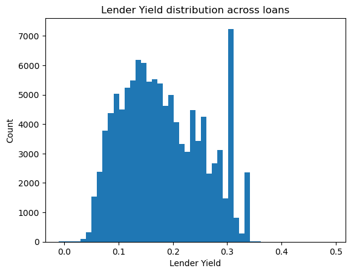

```python
#creating a histogram to view the distribution of Borrower APR across the data frame.
#Lender yield is APR less servicing fee
plt.hist(data=loancopy, x='LenderYield', bins=50);
plt.xlabel('Lender Yield')
plt.ylabel('Count')
plt.title('Lender Yield distribution across loans');
```

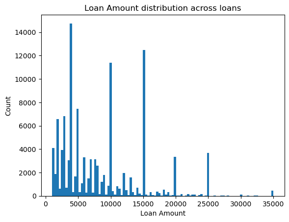

```python
#creating a histogram to view the distribution of loan amount across the data frame
plt.hist(data=loancopy, x='LoanOriginalAmount', bins=100);
plt.xlabel('Loan Amount')
plt.ylabel('Count')
plt.title('Loan Amount distribution across loans');
```

```python
#creating a new column for the dollar amount for lender yield
loancopy['LenderYieldDollar'] = loancopy['LenderYield']*loancopy['LoanOriginalAmount']
```

```python
loancopy.LenderYieldDollar.describe()
```

```
count    113937.000000
mean       1370.315225
std         972.933797
min        -250.000000
25%         634.000000
50%        1139.000000
75%        1898.000000
max        8500.000000
Name: LenderYieldDollar, dtype: float64
```

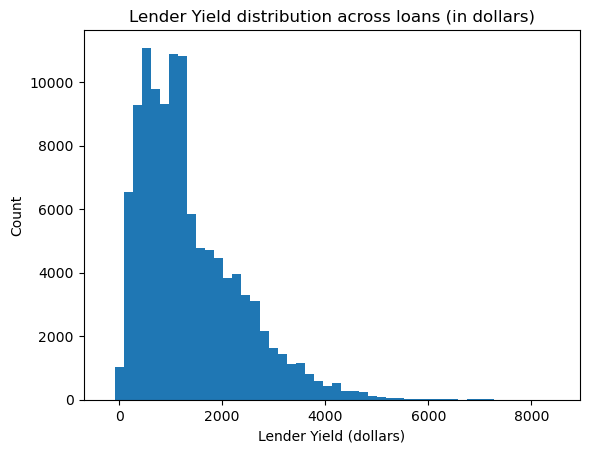

```python
#creating a histogram to view the distribution of lender yield in dollar amount across the data frame
plt.hist(data=loancopy, x='LenderYieldDollar', bins=50);
plt.xlabel('Lender Yield (dollars)')
plt.ylabel('Count')
plt.title('Lender Yield distribution across loans (in dollars)');
```

```python
#creating a new column for the dollar amount for Borrower APR
loancopy['BorrowerAPRDollar'] = loancopy['BorrowerAPR']*loancopy['LoanOriginalAmount']
```

```python
loancopy.BorrowerAPRDollar.describe()
```

```
count    113937.000000
mean       1662.325938
std        1166.210663
min          16.500000
25%         768.840000
50%        1371.400000
75%        2333.250000
max        9155.750000
Name: BorrowerAPRDollar, dtype: float64
```

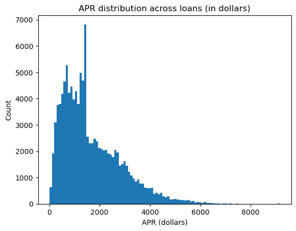

```python
plt.hist(data=loancopy, x='BorrowerAPRDollar', bins=100);
plt.xlabel('APR (dollars)')
plt.ylabel('Count')
plt.title('APR distribution across loans (in dollars)');
```

```python
# Mapping employment status
#Employed, full-time, self-employed are mapped to 'employed', not available and other mapped to 'other',

status = {'Full-time':'Employed', 'Self-employed':'Employed',
           'Not available': 'Other' }

# Function to apply
def emply_status(loancopy):
    if loancopy['EmploymentStatus'] in status.keys():
        description = status[loancopy['EmploymentStatus']]
        return description
    else:
        return loancopy['EmploymentStatus']
```

```python
loancopy.EmploymentStatus.value_counts()
```

```
Employed         67322
Full-time        26355
Self-employed     6134
Not available     5347
Other             3806
Part-time         1088
Not employed       835
Retired            795
Name: EmploymentStatus, dtype: int64
```

```python
loancopy['EmploymentStatus'] = loancopy.apply(emply_status, axis=1)
```

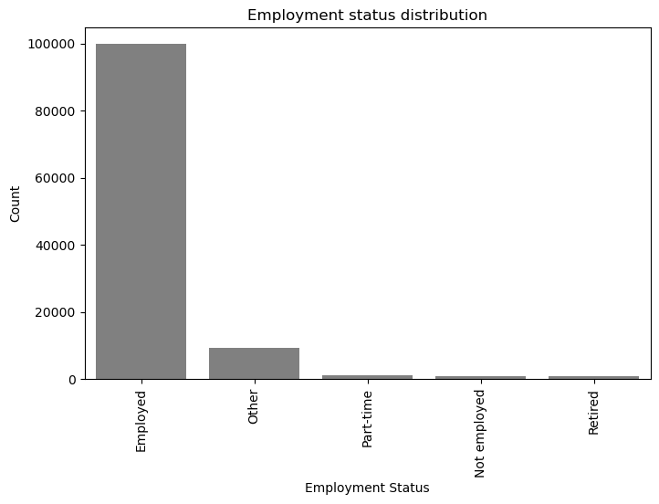

```python
#plot of employement status across borrowers
plt.figure(figsize = [8, 5])
order=loancopy.EmploymentStatus.value_counts().index
sb.countplot(data=loancopy, x='EmploymentStatus', color='Grey', order=order)
plt.xticks(rotation=90);
plt.xlabel('Employment Status')
plt.ylabel('Count')
plt.title('Employment status distribution');
```

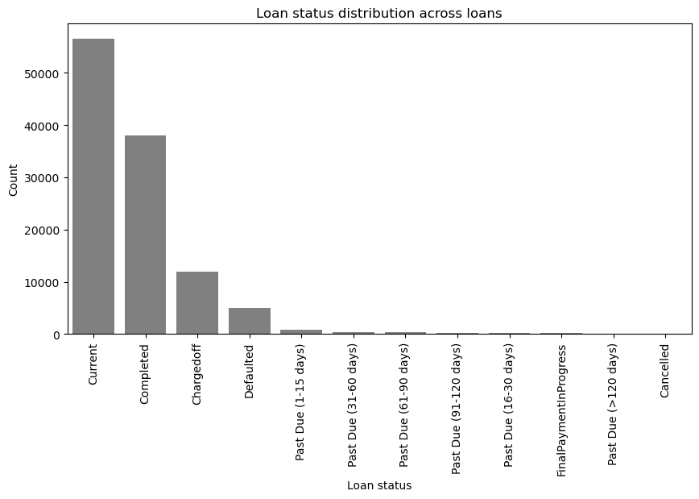

```python
#bar chart showing the loan status across the dataset
plt.figure(figsize = [10, 5])
order=loancopy.LoanStatus.value_counts().index
sb.countplot(data=loancopy, x='LoanStatus', color='grey', order=order)
plt.xticks(rotation=90);
plt.xlabel('Loan status')
plt.ylabel('Count')
plt.title('Loan status distribution across loans');
```

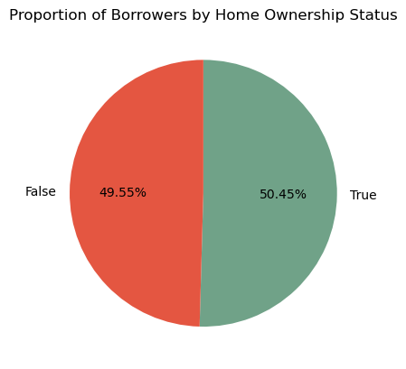

```python
#Distribution of homeownership amongst borrowers
sorted_counts = loancopy['IsBorrowerHomeowner'].value_counts()
plt.pie(sorted_counts, labels = sorted_counts.index, startangle=90,
        counterclock = False, autopct='%.2f%%', colors=['#70A288', '#E45641']);
plt.title('Proportion of Borrowers by Home Ownership Status');
```

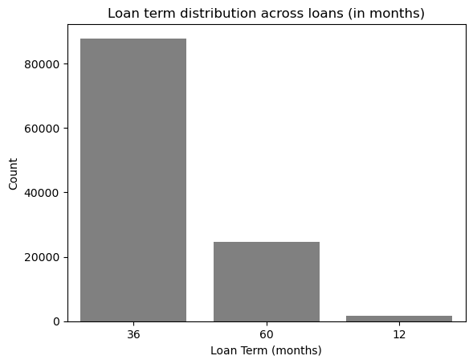

```python
#distribution of loan terms
order=loancopy.Term.value_counts().index
sb.countplot(data=loancopy, x='Term', color='grey', order=order);
plt.xlabel('Loan Term (months)')
plt.ylabel('Count')
plt.title('Loan term distribution across loans (in months)');
```

```python
# The Listingcategory contains numeric values for different categories of loan which is not helpful,
#so Mapping listing category from numeric to text
#Categories less than 1000 counts (<0.8 %) of the total listing were mapped to others

listing = {0:'Not available',1: 'Debt Consolidation',
           2: 'Home Improvement', 3:'Business',
           4: 'Personal loan', 6: 'Auto',
           13: 'Household Expenses', 15: 'Medical/Dental'}

# Function to apply
def listing_key(loancopy):
    if loancopy['ListingCategory (numeric)'] in listing.keys():
        fulldescription = listing[loancopy['ListingCategory (numeric)']]
        return fulldescription
    else:
        return 'others'
```

```python
loancopy['ListingCategory (numeric)'] = loancopy.apply(listing_key, axis=1)
```

```python
loancopy.rename(columns={'ListingCategory (numeric)': 'ListingCategory'}, inplace=True)
```

```python
Listingcat_items = loancopy.ListingCategory.value_counts()
```

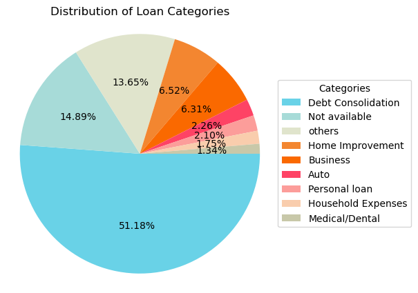

```python
plt.figure(figsize=(8,5))
colors = ['#69D2E7', '#A7DBD8', '#E0E4CC', '#F38630', '#FA6900', '#FE4365', '#FC9D9A', '#F9CDAD', '#C8C8A9']
plt.pie(Listingcat_items, counterclock = False, autopct='%.2f%%', colors=colors)
plt.legend(labels = Listingcat_items.index,
          title="Categories",
          loc="center left",
          bbox_to_anchor=(1, 0, 0.5, 1))
plt.axis('square');
plt.title('Distribution of Loan Categories');
```

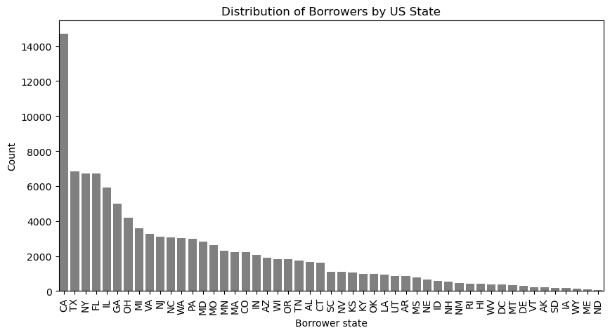

```python
#distribution of borrowers across states
order=loancopy.BorrowerState.value_counts().index
plt.figure(figsize=(10,5))
sb.countplot(data=loancopy, x='BorrowerState', color='grey', order=order);
plt.xticks(rotation=90);
plt.xlabel('Borrower state')
plt.ylabel('Count')
plt.title('Distribution of Borrowers by US State');
```

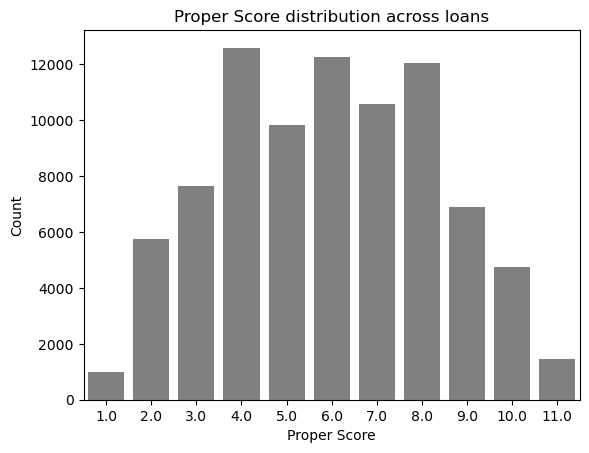

```python
#distribution of proper score
sb.countplot(data=loancopy, x='ProsperScore', color='grey');
#1 is the highest risk of default while 11 is the lowest risk of default.
#higher score indicates higher creditworthiness
plt.xlabel('Proper Score')
plt.ylabel('Count')
plt.title('Proper Score distribution across loans');
```

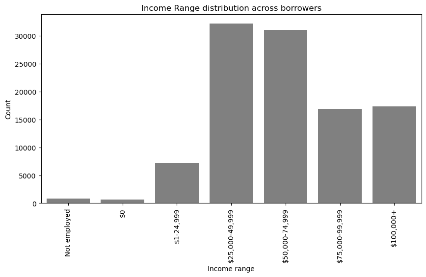

```python
loancopy.IncomeRange.value_counts()

#Set income range to a categorical variable for smooth visualization
income_range = ['Not employed', '$0', '$1-24,999', '$25,000-49,999',
                       '$50,000-74,999', '$75,000-99,999','$100,000+']
iclasses = pd.api.types.CategoricalDtype(ordered=True, categories=income_range)
loancopy['IncomeRange'] = loancopy['IncomeRange'].astype(iclasses)

# excluding the not displayed category
income_range = ['Not employed', '$0', '$1-24,999', '$25,000-49,999',
                       '$50,000-74,999', '$75,000-99,999','$100,000+']

# creating a subset of loancopy dataframe
loan_subset2 = loancopy[loancopy['IncomeRange'].isin(income_range)]

#creating a plot of income range distribution
plt.figure(figsize=(10,5))
sb.countplot(data=loan_subset2, x='IncomeRange', color='grey');
plt.xticks(rotation = 90);
plt.xlabel('Income range')
plt.ylabel('Count')
plt.title('Income Range distribution across borrowers');
```

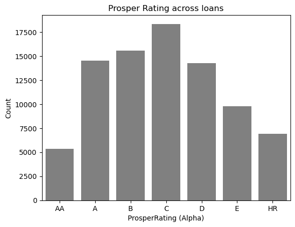

```python
#ordering the categorical variable prosper rating from lowest risk to highest risk
rating = ['AA', 'A', 'B', 'C', 'D', 'E', 'HR']
ratingclasses = pd.api.types.CategoricalDtype(ordered=True, categories=rating)
loancopy['ProsperRating (Alpha)'] = loancopy['ProsperRating (Alpha)'].astype(ratingclasses)

#distribution of prosper rating
sb.countplot(data=loancopy, x='ProsperRating (Alpha)', color='grey');
#HA means highest risk while AA means lowest risk
plt.xlabel('ProsperRating (Alpha)')
plt.ylabel('Count')
plt.title('Prosper Rating across loans');
```

### Discuss the distribution(s) of your variable(s) of interest. Were there any unusual points? Did you need to perform any transformations?

The borrower rate and borrower APR follow a bimodal distribution pattern, ranging from 0.1 to 0.4. Loan amounts range from approximately 1,000 to 35,000 dollars, with most loans falling within the 1,000 to 15,000 dollars range. The majority of loans are currently ongoing, with a significant number already completed and only a few past due. Home ownership is split equally between owners and non-owners. The majority of loans have a 36-month term, with a small proportion having a 12-month term. The most common listing category for Prosper loans is debt consolidation, accounting for about half of all loans. Other categories include home improvement, business, auto, and household expenses. The distribution of borrowers by state shows the highest number of borrowers are California residents, while the least number of borrowers are from North Dakota. However, borrowers come from all 50 states in the US. Finally, a large number of borrowers fall within the income range of 25,000 to 74,999 dollars.

## Bivariate Exploration

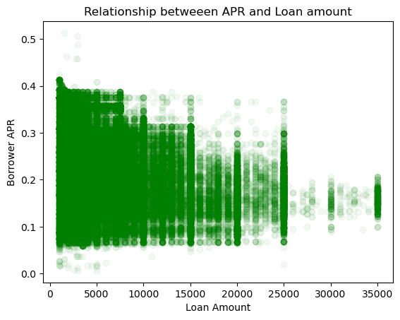

```python
#Relationship between loan original amount and APR
sb.regplot(data=loancopy, x='LoanOriginalAmount', y='BorrowerAPR', scatter_kws = {'alpha':0.05},
                     fit_reg=False, color='green');
plt.xlabel('Loan Amount')
plt.ylabel('Borrower APR')
plt.title('Relationship betweeen APR and Loan amount');

#no defined relationship. The APR does not seem to dependent on the amount of the loan
```

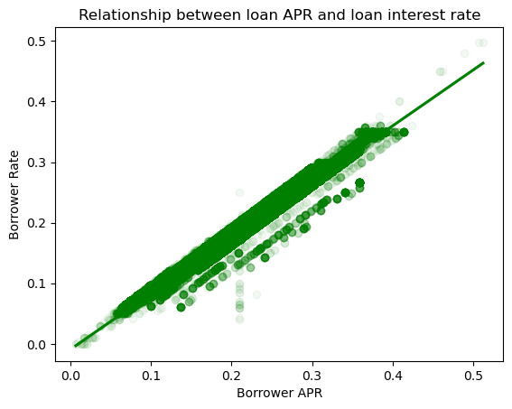

```python
#Relationship between loan interest rate and loan APR
sb.regplot(data=loancopy, x='BorrowerAPR', y='BorrowerRate', scatter_kws = {'alpha':0.05},
                      fit_reg=True, color='green');
#linear relationship
plt.xlabel('Borrower APR')
plt.ylabel('Borrower Rate')
plt.title('Relationship between loan APR and loan interest rate');
```

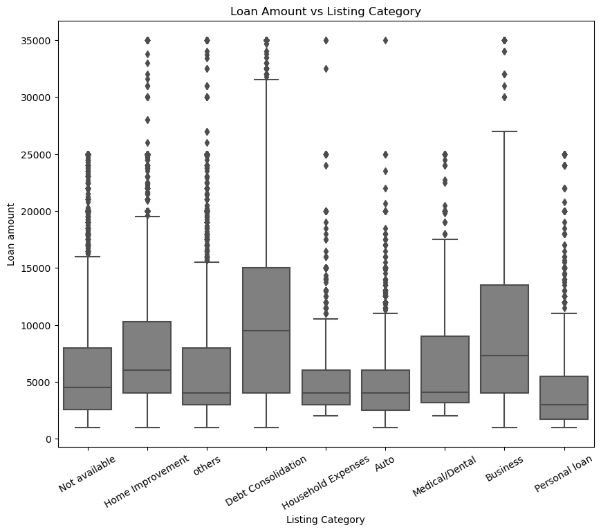

```python
#relationship between loan amount and category listed for the loan
plt.figure(figsize=(10,8))
sb.boxplot(data=loancopy, x='ListingCategory', y='LoanOriginalAmount', color='Grey');
plt.xticks(rotation=30);
plt.xlabel('Listing Category')
plt.ylabel('Loan amount')
plt.title('Loan Amount vs Listing Category');
```

```python
loancopy.LoanStatus.value_counts()
```

```
Current                   56576
Completed                 38074
Chargedoff                11992
Defaulted                  5018
Past Due (1-15 days)        806
Past Due (31-60 days)       363
Past Due (61-90 days)       313
Past Due (91-120 days)      304
Past Due (16-30 days)       265
FinalPaymentInProgress      205
Past Due (>120 days)         16
Cancelled                     5
Name: LoanStatus, dtype: int64
```

```python
# Since there's a lot of categories for LoanStatus, I'll create a list of the top four categories
loan_status_subset = ['Current', 'Completed', 'Chargedoff', 'Defaulted']

# creating a subset of loancopy dataframe to include observations with the first four LoanStatus categories
loan_subset = loancopy[loancopy['LoanStatus'].isin(loan_status_subset)]
```

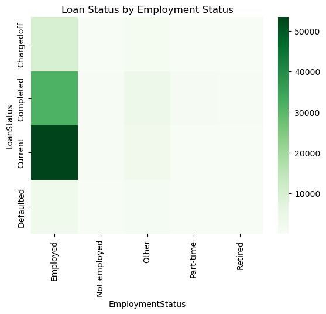

```python
#creating a heat map to show the relationship between loan status and employment status
cross_tab = pd.crosstab(loan_subset['LoanStatus'], loan_subset['EmploymentStatus'])
sb.heatmap(cross_tab, cmap='Greens')
plt.title('Loan Status by Employment Status')
plt.show()
```

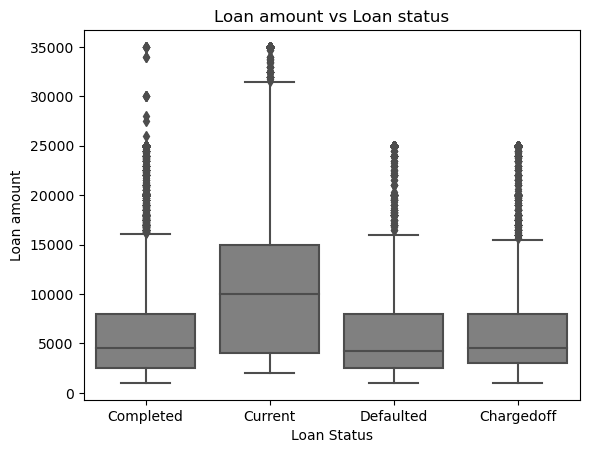

```python
#Relationship between loan status and loan amount
sb.boxplot(data=loan_subset, x='LoanStatus', y='LoanOriginalAmount', color='Grey');
plt.xlabel('Loan Status')
plt.ylabel('Loan amount')
plt.title('Loan amount vs Loan status');
```

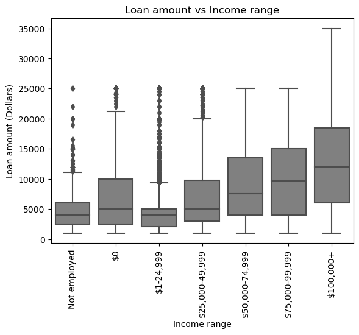

```python
#Relationship between income range and loan amount
sb.boxplot(data=loan_subset2, x='IncomeRange', y='LoanOriginalAmount', color='grey');
plt.xticks(rotation = 90);
plt.xlabel('Income range')
plt.ylabel('Loan amount (Dollars)')
plt.title('Loan amount vs Income range');
```

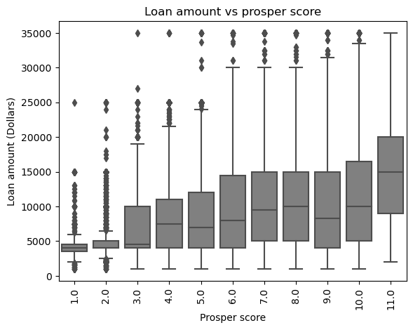

```python
#relationship between prosper score and loan amount
sb.boxplot(data=loancopy, x='ProsperScore', y='LoanOriginalAmount', color='grey');
plt.xticks(rotation = 90);
plt.xlabel('Prosper score')
plt.ylabel('Loan amount (Dollars)')
plt.title('Loan amount vs prosper score');
```

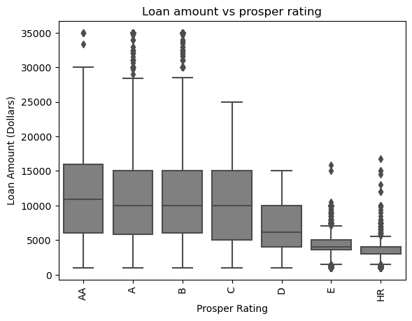

```python
#relationship between prosper rating and loan amount
sb.boxplot(data=loancopy, x='ProsperRating (Alpha)', y='LoanOriginalAmount', color='grey');
plt.xticks(rotation = 90);
plt.xlabel('Prosper Rating')
plt.ylabel('Loan Amount (Dollars)')
plt.title('Loan amount vs prosper rating');
```

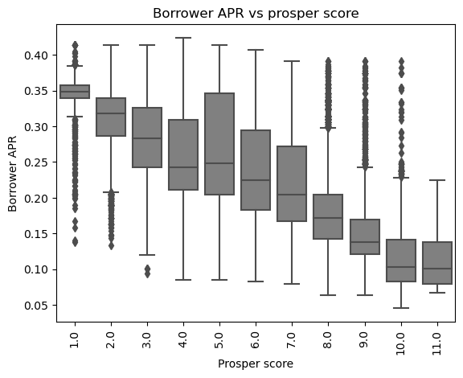

```python
#relationship between prosper score and APR
sb.boxplot(data=loancopy, x='ProsperScore', y='BorrowerAPR', color='grey');
plt.xticks(rotation = 90);
plt.xlabel('Prosper score')
plt.ylabel('Borrower APR')
plt.title('Borrower APR vs prosper score');
```

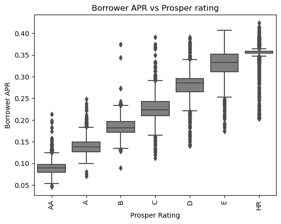

```python
#relationship between prosper rating and APR
sb.boxplot(data=loancopy, x='ProsperRating (Alpha)', y='BorrowerAPR', color='grey');
plt.xticks(rotation = 90);
plt.xlabel('Prosper Rating')
plt.ylabel('Borrower APR')
plt.title('Borrower APR vs Prosper rating');
```

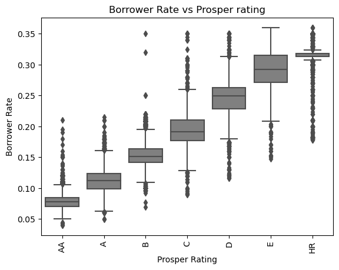

```python
#relationship between prosper rating and Borrower rate
sb.boxplot(data=loancopy, x='ProsperRating (Alpha)', y='BorrowerRate', color='grey');
plt.xticks(rotation = 90);
plt.xlabel('Prosper Rating')
plt.ylabel('Borrower Rate')
plt.title('Borrower Rate vs Prosper rating');
```

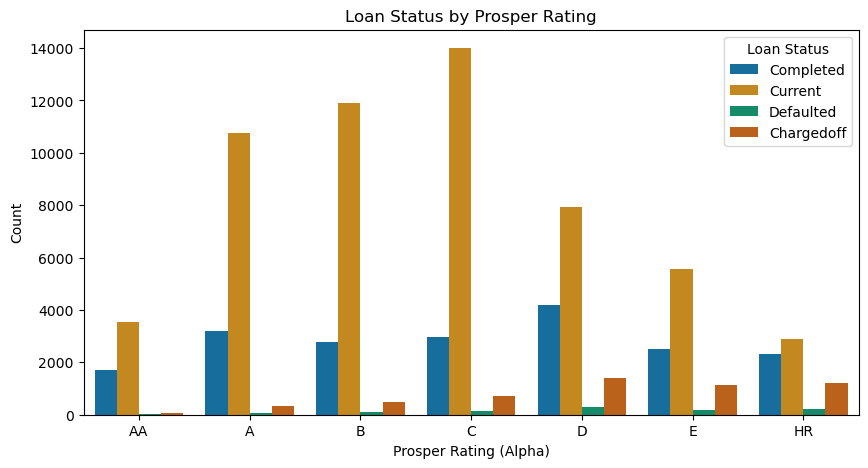

```python
# Plot of LoanStatus for each value of ProsperRating (Alpha)
plt.figure(figsize=[10,5])
rating_order = ['AA', 'A', 'B', 'C', 'D', 'E', 'HR']
sb.countplot(data=loan_subset, x='ProsperRating (Alpha)', hue='LoanStatus', order=rating_order, palette='colorblind')
plt.xlabel('Prosper Rating (Alpha)')
plt.ylabel('Count')
plt.title('Loan Status by Prosper Rating')
plt.legend(title='Loan Status');
```

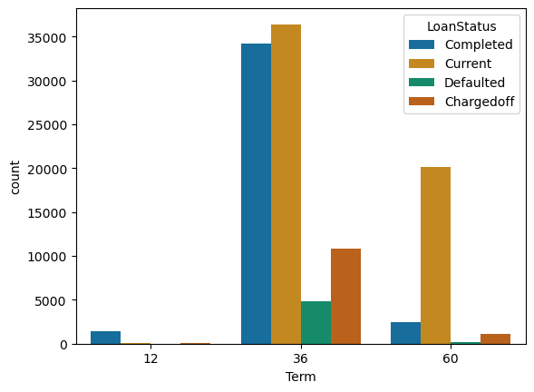

```python
#plot of Loan status and term
sb.countplot(data=loan_subset, x='Term', hue='LoanStatus', palette='colorblind');
```

### Talk about some of the relationships you observed in this part of the investigation. How did the feature(s) of interest vary with other features in the dataset?

The relationship between APR and loan amount does not show any clear dependencies, with varying APRs across different loan amounts. This calls for further investigation, as seen in the multivariate exploration. However, a linear relationship between APR and interest rate is evident, with higher interest rates leading to higher APRs.

A plot of loan amount vs. listing category shows that the highest loan amounts were taken out for debt consolidation, followed by business loans.

Analysis of the relationship between employment status and loan status reveals that more loans are granted to the employed than to the unemployed.

The higher a borrower's prosper score (creditworthiness), the higher their loan amount. Borrowers with lower prosper scores (1.0 and 2.0) received the least amount of loan. However, there were some outliers, receiving as much as $25,000 in loan. A plot of prosper rating vs. loan amount shows a similar trend, with lower prosper scores not necessarily implying a low prosper rating, as both are based on different criteria.

Plots of APR vs. prosper score and prosper rating show that better creditworthiness leads to lower APR, while higher risk loans lead to higher APR.

A plot of loan status against prosper rating shows that there are not many active high-risk and low-risk loans, potentially due to the limited number of such loans to begin with. There are only about 5,000 low-risk loans (AA) and almost 7,500 high-risk loans (HR). However, high-risk loans have higher default and charged-off rates when compared with low-risk loans, which have substantially lower counts for defaulted and charged-off loans.

Most defaulted and charged-off loans have a term of 36 months.

## Multivariate Exploration

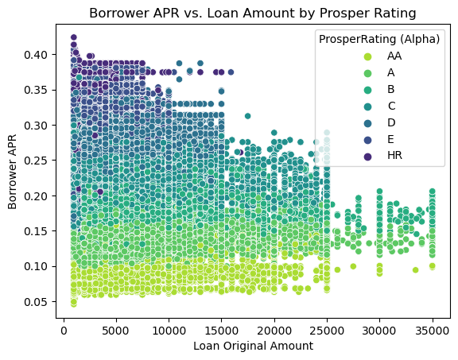

```python
#plot of APR against loan amount using prosper rating as the third dimension
sb.scatterplot(data=loancopy, x='LoanOriginalAmount', y='BorrowerAPR',
               hue='ProsperRating (Alpha)', palette='viridis_r')
plt.xlabel('Loan Original Amount')
plt.ylabel('Borrower APR')
plt.title('Borrower APR vs. Loan Amount by Prosper Rating')

#high risk is associated with deeper colors
```

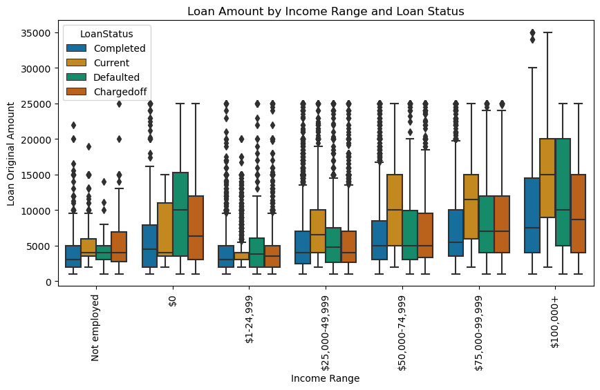

```python
#plot of Loan amount vy income range with loan status as the third dimension
plt.figure(figsize=[10,5])
income_order = ['Not employed', '$0', '$1-24,999', '$25,000-49,999',
                       '$50,000-74,999', '$75,000-99,999','$100,000+']
sb.boxplot(data=loan_subset, x='IncomeRange', y='LoanOriginalAmount',
               hue='LoanStatus',  order=income_order, palette='colorblind')
plt.xlabel('Income Range')
plt.ylabel('Loan Original Amount')
plt.title('Loan Amount by Income Range and Loan Status')
plt.xticks(rotation = 90);
```

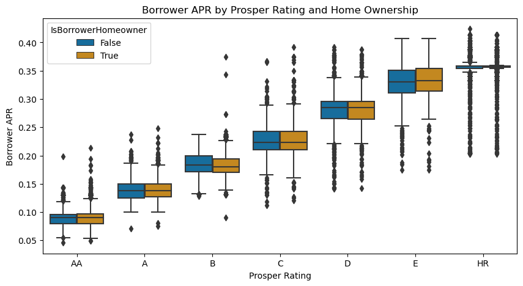

```python
#plot of APR against prosper rating with home ownership in the third dimension
plt.figure(figsize=[10,5])
sb.boxplot(data=loan_subset, x='ProsperRating (Alpha)', y='BorrowerAPR',
           hue='IsBorrowerHomeowner', palette='colorblind')
plt.xlabel('Prosper Rating')
plt.ylabel('Borrower APR')
plt.title('Borrower APR by Prosper Rating and Home Ownership');

#Home ownership does not affect BorrowerAPR
```

### Talk about some of the relationships you observed in this part of the investigation. Were there features that strengthened each other in terms of looking at your feature(s) of interest?

Definitely the multivariate plot of APR against loan amount and prosper rating further strengthened the dependance of APR on creditworthiness. It also shows that lesser dollar amount of loan was given out to less credit worthy borrowers. The reverse is true for credit worthy borrowers.

### Were there any interesting or surprising interactions between features?

Home ownership does not seem to affect borrower APR nor creditworthiness

## Conclusions

The loan dataset has variables such as borrower rate, borrower APR, loan amount, loan status, home ownership, loan term, listing category, income range, and prosper score. The data set did not require much wrangling efforts as it appears pretty much tidy and clean. Since the APR column contains some null values, they were filled with median calues across the dataset. Employment statuses were re-classified and listing categories were mapped from numeric values to texts.

The loan amount ranges from 1,000 to 35,000 dollars, with most loans falling within the 1,000 to 15,000 dollars range. The borrower rate and APR show a bimodal distribution. The loan status shows that most loans are still ongoing, with a smaller number past due or completed. The highest number of borrowers are in California, while North Dakota has the least. The borrowers' income range mostly falls within 25,000 to 74,999 dollars.

An interesting feature that was not explored would be the factors affecting prosper score and prosper rating. Is this dependent on the borrower or on the use of the loans. This would be interesting to know.